# **Loan Default Prediction**

## **Problem Definition**

Loan default prediction is a predictive modeling task in which a financial institution aims to estimate the likelihood that a borrower will fail to meet their scheduled loan obligations. More formally:

Given a set of historical loan applications and their associated outcomes (i.e., whether the borrower eventually defaulted or fully repaid), A range of borrower attributes such as demographic information, credit history, financial stability indicators, and loan characteristics (e.g., interest rate, loan amount, loan term), as well as potentially external data like macroeconomic factors or industry trends.

- Objective:

**Develop a predictive model that, for a new loan applicant, outputs a probability or classification indicating the risk of default.**

- Key Considerations:

Accuracy vs. Practical Impact: The model should not only be statistically accurate but also provide insights that support effective credit risk management and decision-making.

Regulatory and Ethical Standards: The prediction should adhere to compliance standards (e.g., fair lending laws) and avoid unfair discrimination against protected groups.

Timeliness and Scalability: Predictions must be timely enough to support real-time or near real-time credit decisions and scale across large applicant volumes.

Interpretability and Actionability: The model’s outputs should be interpretable so that credit officers and risk managers can understand the reasons behind a given risk assessment and take appropriate actions, such as adjusting lending terms or initiating loss mitigation strategies.

In essence, the problem is about leveraging historical data and advanced analytics to preemptively identify potential defaulters, thereby mitigating financial risk and informing better lending decisions.

### **The Context:**

**Loan default prediction is critically important for financial institutions for several key reasons:**

- Risk Mitigation and Loss Reduction: Financial institutions earn revenue primarily by lending money and collecting interest. However, when borrowers default, the institution not only loses the principal amount but also incurs additional costs such as legal expenses and loan restructuring efforts. By accurately predicting which borrowers are likely to default, banks can proactively minimize their exposure to high-risk loans. This leads to a reduction in non-performing assets (NPAs) and helps maintain a healthier loan portfolio.
- Capital Efficiency and Regulatory Compliance: Regulatory frameworks require banks to maintain sufficient capital reserves based on the risk profile of their lending activities. Accurate default predictions enable more precise estimation of risk-weighted assets and the capital required. This means the institution can allocate its capital more efficiently, ensuring compliance with regulations while not over-allocating capital that could be used productively elsewhere.
- Pricing and Product Structuring: When a financial institution understands a borrower’s likelihood of default, it can tailor loan terms and interest rates more effectively. High-risk borrowers might face slightly higher interest rates or additional collateral requirements, while low-risk borrowers can enjoy more favorable terms. Accurate predictions thus allow for more competitive and personalized product offerings, ultimately improving market positioning and profitability.
- Informed Credit Policy and Underwriting Decisions: Default prediction models provide data-driven insights that can shape lending policies. By integrating predictive analytics into credit decision-making, underwriters can better identify red flags, validate the borrower’s creditworthiness, and refine lending criteria. Over time, this leads to more consistent decision-making and a lower default rate.
- Improved Customer Relationship and Retention: Default prediction isn’t just about denying credit to risky borrowers; it’s also about identifying early warning signs so the institution can intervene. For instance, if a model forecasts potential financial distress, the bank might offer a loan modification, financial counseling, or restructuring options before the situation deteriorates. Such proactive engagement can build trust, enhance the customer’s experience, and improve long-term customer relationships.
- Enhanced Strategic Planning and Forecasting: A better understanding of default risk contributes to more accurate long-term planning. Institutions can simulate different economic scenarios—like downturns or changes in interest rates—and gauge how their loan portfolios might perform under stress. This forward-looking capability aids in strategic decision-making, optimizing loan portfolios, and preparing contingencies.

### **The objective:**

The main objective of the loan default prediction project should be to develop a reliable, data-driven model that accurately estimates the probability of each borrower defaulting on their loan. This objective can be broken down into the following actionable goals:

- Risk Stratification: Provide a quantitative assessment of risk for each loan applicant, enabling the financial institution to classify borrowers into categories (e.g., low, medium, or high risk).
- Decision Support for Underwriting: Enhance the credit underwriting process by offering insights that inform lending decisions—such as whether to approve, decline, or request more collateral—and guide the structuring of loan terms (interest rates, duration, etc.) based on risk level.
- Portfolio Risk Management: Enable the institution to proactively manage its overall loan portfolio by identifying potential problem loans early, improving the quality and stability of the lending book, and optimizing resource allocation (e.g., more stringent monitoring for higher-risk customers).
- Compliance and Fairness: Ensure that the predictive model’s recommendations adhere to regulatory and ethical standards, preventing unfair bias and ensuring equitable lending practices.
- Scalable, Timely Insights: Deliver predictions efficiently and at scale, integrating seamlessly with existing workflows and systems, and allowing for quick responses to changes in economic conditions or applicant profiles.

In essence, the objective is not merely to predict defaults accurately but to create a practical tool that supports smarter, more proactive credit risk management, ultimately improving both financial performance and customer relationships.

### **The key questions:**

Based on the previous objectives and problem context, several key questions emerge that the project aims to address:

- Data and Feature Relevance:

What borrower characteristics, loan attributes, and external factors (e.g., macroeconomic indicators) are most predictive of default?

Which data sources are available and reliable, and how can they be integrated effectively?

- Model Performance and Validation:

How accurately can the model predict defaults across different segments of borrowers and loan types?

How should model performance be evaluated? Which metrics (e.g., AUC, precision, recall, F1-score, KS statistic) best reflect business goals?

- Risk Thresholds and Decision Criteria:

How should the institution set optimal thresholds for approving, denying, or conditionally offering loans?

What is the trade-off between minimizing false approvals (loans given to borrowers who default) and false rejections (turning away creditworthy applicants)?

- Interpretability and Explainability:

How can the model’s predictions be explained to stakeholders such as underwriters, risk managers, and regulators?

Can the model provide actionable insights (e.g., which factors led to a high-risk prediction) that help guide credit policy and remediation strategies?

- Integration and Implementation:

How will the predictive model be deployed in existing workflows and decision systems? What governance, monitoring, and maintenance processes need to be in place to ensure the model remains accurate and aligned with business goals over time?

- Strategic and Financial Impact:

What tangible benefits (e.g., reduction in default rates, improved portfolio quality, optimized capital allocation) can be realized by using this model?

How do model insights influence long-term lending strategies and policies?

Addressing these questions will guide the development, deployment, and ongoing refinement of the loan default prediction model, ensuring it not only performs technically but also supports the institution’s broader strategic and ethical considerations.

### **The problem formulation**

In simpler terms, the problem is about using historical loan and customer data to build a predictive model that can estimate the likelihood that a new loan applicant will fail to repay their loan. Data science techniques are employed to uncover patterns and relationships within the data—such as which borrower characteristics, financial indicators, or loan terms are most associated with default—and then use these insights to inform future lending decisions. Ultimately, we aim to transform raw data into actionable risk assessments that help the institution approve loans more confidently, set appropriate interest rates, manage portfolio risk, and comply with regulatory standards.

## **Data Description:**

The Home Equity dataset (HMEQ) contains baseline and loan performance information for 5,960 recent home equity loans. The target (BAD) is a binary variable that indicates whether an applicant has ultimately defaulted or has been severely delinquent. This adverse outcome occurred in 1,189 cases (20 percent). 12 input variables were registered for each applicant.

- **BAD:** 1 = Client defaulted on loan, 0 = loan repaid
- **LOAN:** Amount of loan approved.
- **MORTDUE:** Amount due on the existing mortgage.
- **VALUE:** Current value of the property.
- **REASON:** Reason for the loan request. (HomeImp = home improvement, DebtCon= debt consolidation which means taking out a new loan to pay off other liabilities and consumer debts)
- **JOB:** The type of job that loan applicant has such as manager, self, etc.
- **YOJ:** Years at present job.
- **DEROG:** Number of major derogatory reports (which indicates a serious delinquency or late payments).
- **DELINQ:** Number of delinquent credit lines (a line of credit becomes delinquent when a borrower does not make the minimum required payments 30 to 60 days past the day on which the payments were due).
- **CLAGE:** Age of the oldest credit line in months.
- **NINQ:** Number of recent credit inquiries.
- **CLNO:** Number of existing credit lines.
- **DEBTINC:** Debt-to-income ratio (all your monthly debt payments divided by your gross monthly income. This number is one way lenders measure your ability to manage the monthly payments to repay the money you plan to borrow.

## **Import the necessary libraries and Data**

```python
import numpy as np
import pandas as pd
import matplotlib.pyplot as plt
import seaborn as sns
sns.set_theme()

from sklearn.model_selection import train_test_split

from sklearn.linear_model import LogisticRegression

from sklearn import metrics
from sklearn.metrics import confusion_matrix, classification_report,accuracy_score,precision_score,recall_score,f1_score

from sklearn import tree
from sklearn.tree import DecisionTreeClassifier

from sklearn.ensemble import BaggingClassifier
from sklearn.ensemble import RandomForestClassifier

import scipy.stats as stats

from sklearn.model_selection import GridSearchCV


import warnings
warnings.filterwarnings('ignore')
```

## **Exploratory Data Analysis (EDA) and Visualization**

- EDA is an important part of any project involving data.
- It is important to investigate and understand the data better before building a model with it.
- A few questions have been mentioned below which will help you approach the analysis in the right manner and generate insights from the data.
- A thorough analysis of the data, in addition to the questions mentioned below, should be done.

**Leading Questions**:

1. What is the range of values for the loan amount variable "LOAN"?
2. How does the distribution of years at present job "YOJ" vary across the dataset?
3. How many unique categories are there in the REASON variable?
4. What is the most common category in the JOB variable?
5. Is there a relationship between the REASON variable and the proportion of applicants who defaulted on their loan?
6. Do applicants who default have a significantly different loan amount compared to those who repay their loan?
7. Is there a correlation between the value of the property and the loan default rate?
8. Do applicants who default have a significantly different mortgage amount compared to those who repay their loan?

#### **1. Data Preprocessing**

- **Exploratory Data Analysis (EDA):**

Understand the distribution of each feature, detect missing values, and identify potential outliers.

- **Bivariate Analysis**

**Correlation:** Analyze correlations between numeric variables to understand relationships and potential collinearity.

**Cross-Tabulation:** For categorical variables, use cross-tabulation with the target variable to uncover patterns or trends in default rates across different categories.

- **Handling Missing Values:** Decide whether to impute missing values using statistical methods (mean, median, mode) or advanced techniques (k-Nearest Neighbors imputation) or to remove them.
- **Outlier Treatment:** Use boxplots, z-scores, or IQR methods to detect outliers and decide whether to cap, remove, or transform them.
- **Feature Encoding:** Convert categorical variables (REASON, JOB) into numeric representations using one-hot encoding or label encoding.
- **Feature Scaling:** Normalize or standardize numerical features for better model performance.

## **Data Overview**

```python
# Load the dataset
file_path = 'hmeq.csv'  # Update this path to the correct location of your dataset
hmeq_data = pd.read_csv(file_path)

# Inspect the data structure
data_info = {
    "Shape": hmeq_data.shape,
    "Columns": hmeq_data.columns.tolist(),
    "Data Types": hmeq_data.dtypes,
    "Head": hmeq_data.head(),
    "Missing Values": hmeq_data.isnull().sum()
}

data_info
```

```
{'Shape': (5960, 13),
 'Columns': ['BAD',
  'LOAN',
  'MORTDUE',
  'VALUE',
  'REASON',
  'JOB',
  'YOJ',
  'DEROG',
  'DELINQ',
  'CLAGE',
  'NINQ',
  'CLNO',
  'DEBTINC'],
 'Data Types': BAD          int64
 LOAN         int64
 MORTDUE    float64
 VALUE      float64
 REASON      object
 JOB         object
 YOJ        float64
 DEROG      float64
 DELINQ     float64
 CLAGE      float64
 NINQ       float64
 CLNO       float64
 DEBTINC    float64
 dtype: object,
 'Head':    BAD  LOAN  MORTDUE     VALUE   REASON     JOB   YOJ  DEROG  DELINQ  \
 0    1  1100  25860.0   39025.0  HomeImp   Other  10.5    0.0     0.0
 1    1  1300  70053.0   68400.0  HomeImp   Other   7.0    0.0     2.0
 2    1  1500  13500.0   16700.0  HomeImp   Other   4.0    0.0     0.0
 3    1  1500      NaN       NaN      NaN     NaN   NaN    NaN     NaN
 4    0  1700  97800.0  112000.0  HomeImp  Office   3.0    0.0     0.0

         CLAGE  NINQ  CLNO  DEBTINC
 0   94.366667   1.0   9.0      NaN
 1  121.833333   0.0  14.0      NaN
 2  149.466667   1.0  10.0      NaN
 3         NaN   NaN   NaN      NaN
 4   93.333333   0.0  14.0      NaN  ,
 'Missing Values': BAD           0
 LOAN          0
 MORTDUE     518
 VALUE       112
 REASON      252
 JOB         279
 YOJ         515
 DEROG       708
 DELINQ      580
 CLAGE       308
 NINQ        510
 CLNO        222
 DEBTINC    1267
 dtype: int64}
```

Here's an overview of the Home Equity dataset (HMEQ) based on the initial data checks:

Shape of the Dataset: There are 5,960 rows and 13 columns in the dataset.

- **Data Types:**

**Thoughts**

The presence of missing values in several columns will require careful imputation or removal strategies. Both numerical and categorical features are present, necessitating different preprocessing steps. The dataset includes the target variable BAD, which will help us evaluate class imbalance.

## Summary Statistics

```python
# Calculate summary statistics for the dataset
summary_statistics = hmeq_data.describe(include='all')
summary_statistics
```

|  | BAD | LOAN | MORTDUE | VALUE | REASON | JOB | YOJ | DEROG | DELINQ | CLAGE | NINQ | CLNO | DEBTINC |
| --- | --- | --- | --- | --- | --- | --- | --- | --- | --- | --- | --- | --- | --- |
| count | 5960.000000 | 5960.000000 | 5442.000000 | 5848.000000 | 5708 | 5681 | 5445.000000 | 5252.000000 | 5380.000000 | 5652.000000 | 5450.000000 | 5738.000000 | 4693.000000 |
| unique | NaN | NaN | NaN | NaN | 2 | 6 | NaN | NaN | NaN | NaN | NaN | NaN | NaN |
| top | NaN | NaN | NaN | NaN | DebtCon | Other | NaN | NaN | NaN | NaN | NaN | NaN | NaN |
| freq | NaN | NaN | NaN | NaN | 3928 | 2388 | NaN | NaN | NaN | NaN | NaN | NaN | NaN |
| mean | 0.199497 | 18607.969799 | 73760.817200 | 101776.048741 | NaN | NaN | 8.922268 | 0.254570 | 0.449442 | 179.766275 | 1.186055 | 21.296096 | 33.779915 |
| std | 0.399656 | 11207.480417 | 44457.609458 | 57385.775334 | NaN | NaN | 7.573982 | 0.846047 | 1.127266 | 85.810092 | 1.728675 | 10.138933 | 8.601746 |
| min | 0.000000 | 1100.000000 | 2063.000000 | 8000.000000 | NaN | NaN | 0.000000 | 0.000000 | 0.000000 | 0.000000 | 0.000000 | 0.000000 | 0.524499 |
| 25% | 0.000000 | 11100.000000 | 46276.000000 | 66075.500000 | NaN | NaN | 3.000000 | 0.000000 | 0.000000 | 115.116702 | 0.000000 | 15.000000 | 29.140031 |
| 50% | 0.000000 | 16300.000000 | 65019.000000 | 89235.500000 | NaN | NaN | 7.000000 | 0.000000 | 0.000000 | 173.466667 | 1.000000 | 20.000000 | 34.818262 |
| 75% | 0.000000 | 23300.000000 | 91488.000000 | 119824.250000 | NaN | NaN | 13.000000 | 0.000000 | 0.000000 | 231.562278 | 2.000000 | 26.000000 | 39.003141 |
| max | 1.000000 | 89900.000000 | 399550.000000 | 855909.000000 | NaN | NaN | 41.000000 | 10.000000 | 15.000000 | 1168.233561 | 17.000000 | 71.000000 | 203.312149 |

- **Observations from Summary Statistics**

**Numerical Attributes:**

LOAN:

Mean loan amount: $18,608 Range: $1,100 to $89,900 MORTDUE: (Amount due on existing mortgage)

Mean: $73,761 Range: $2,063 to $399,550 VALUE: (Current property value)

Mean: $101,776 Range: $8,000 to $855,909 YOJ: (Years at present job)

Mean: 8.92 years Range: 0 to 41 years DEROG: (Number of major derogatory reports)

Mean: 0.25 Range: 0 to 10 DELINQ: (Number of delinquent credit lines)

Mean: 0.45 Range: 0 to 15 CLAGE: (Age of the oldest credit line in months)

Mean: 179.77 months Range: 0 to 1,168.23 months NINQ: (Number of recent credit inquiries)

Mean: 1.19 Range: 0 to 17 CLNO: (Number of existing credit lines)

Mean: 21.30 Range: 0 to 71 DEBTINC: (Debt-to-income ratio)

Mean: 33.78% Range: 0.52% to 203.31% Categorical Attributes: REASON:

**Most common reason for loan request is 'Debt Consolidation' (DebtCon).** JOB:

**Most common job category is 'Other'.**

**Overall:**

BAD: (Loan performance)

20% of the loans resulted in defaults or severe delinquencies.

These statistics give us a broad view of the dataset, including typical loan amounts, borrower job stability, and financial behaviors. Each attribute varies significantly, suggesting diverse financial profiles among borrowers. This diversity must be considered when training predictive models, as it can affect model accuracy and generalization.

### **Univariate Analysis**

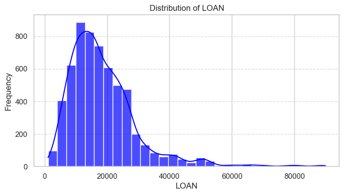

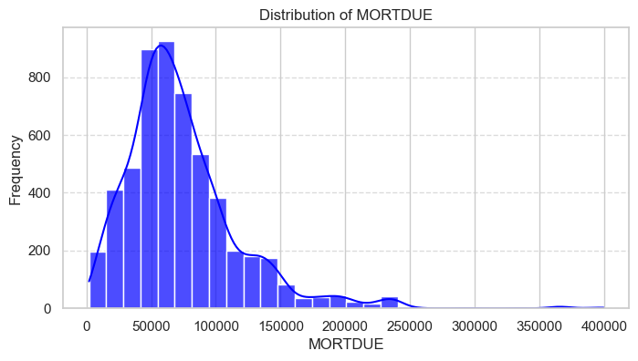

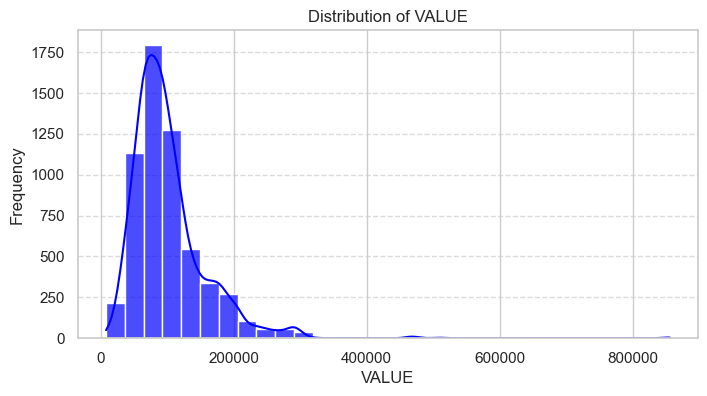

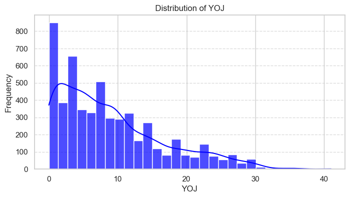

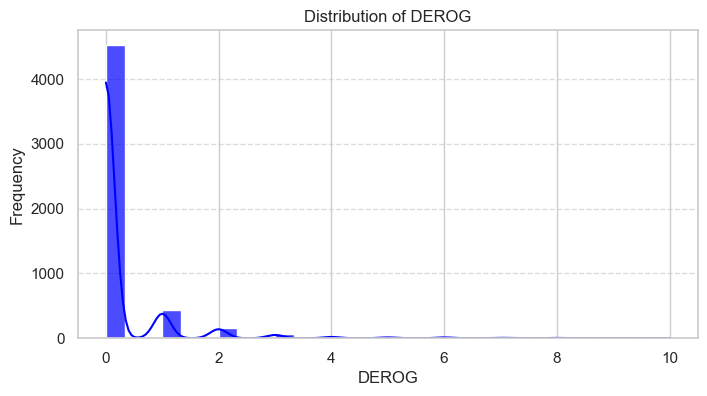

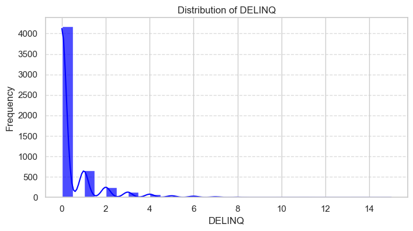

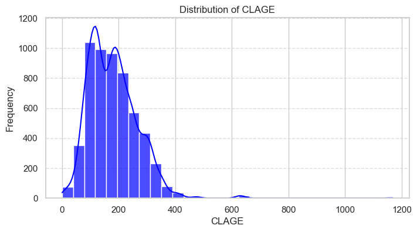

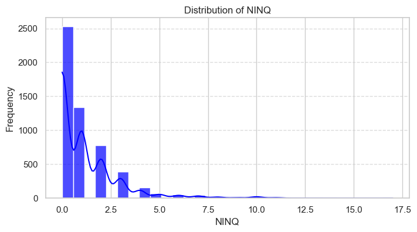

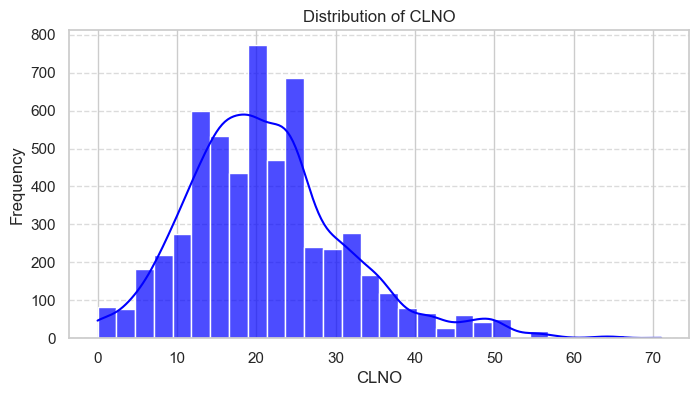

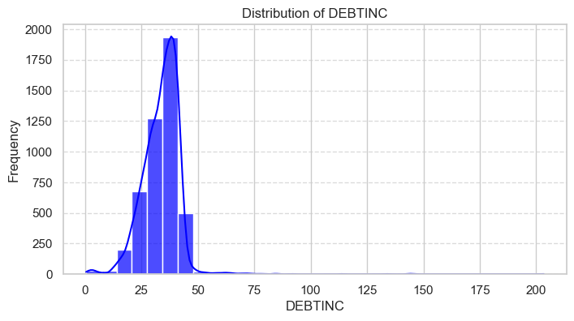

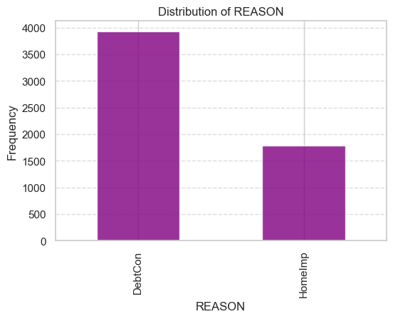

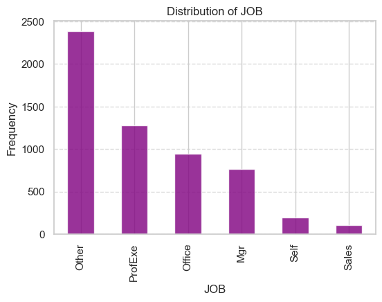

```python
# Set up the plotting environment
sns.set(style="whitegrid")

# Plot distributions for numerical variables
numerical_columns = ['LOAN', 'MORTDUE', 'VALUE', 'YOJ', 'DEROG', 'DELINQ', 'CLAGE', 'NINQ', 'CLNO', 'DEBTINC']

for column in numerical_columns:
    plt.figure(figsize=(8, 4))
    sns.histplot(hmeq_data[column], bins=30, kde=True, color='blue', alpha=0.7)
    plt.title(f'Distribution of {column}')
    plt.xlabel(column)
    plt.ylabel('Frequency')
    plt.grid(axis='y', linestyle='--', alpha=0.7)
    plt.show()

# Frequency distributions for categorical variables
categorical_columns = ['REASON', 'JOB']

for column in categorical_columns:
    plt.figure(figsize=(6, 4))
    hmeq_data[column].value_counts().plot(kind='bar', color='purple', alpha=0.8)
    plt.title(f'Distribution of {column}')
    plt.xlabel(column)
    plt.ylabel('Frequency')
    plt.grid(axis='y', linestyle='--', alpha=0.7)
    plt.show()
```

#### **Observations from Univariable Analysis:**

- **Numerical Variables:**

**LOAN (Loan Amount):**

Distribution is right-skewed, with most values clustered at lower amounts. Few very high loan amounts suggest potential outliers.

**MORTDUE (Mortgage Due):**

Most values are concentrated below $100,000, with a gradual tail extending towards higher amounts.

**VALUE (Property Value):**

Distribution is right-skewed, with a majority of properties valued below $200,000.

**YOJ (Years at Present Job):**

Most values are below 20 years, with a sharp decline as years increase.

**DEROG (Number of Major Derogatory Reports):**

Predominantly 0, with a small number of applicants having significant derogatory reports.

**DELINQ (Number of Delinquent Credit Lines):**

Similar to DEROG, most values are 0, with fewer delinquent lines observed.

**CLAGE (Age of Oldest Credit Line):**

Values spread widely, but most are between 50 and 250 months, with a long tail.

**NINQ (Number of Recent Credit Inquiries):**

Concentrated around 0–5, with diminishing frequency for higher inquiries.

**CLNO (Number of Existing Credit Lines):**

Spread out, with most values concentrated around 10–30 credit lines.

**DEBTINC (Debt-to-Income Ratio):**

Most values fall below 50%, with a sharp drop-off beyond that, suggesting potential outliers.

- **Categorical Variables:**

**REASON:**

### **Bivariate Analysis**

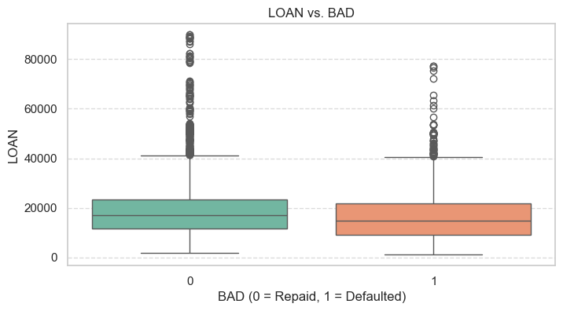

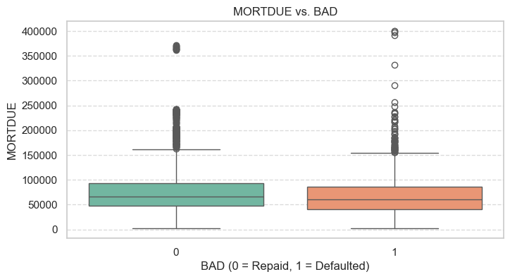

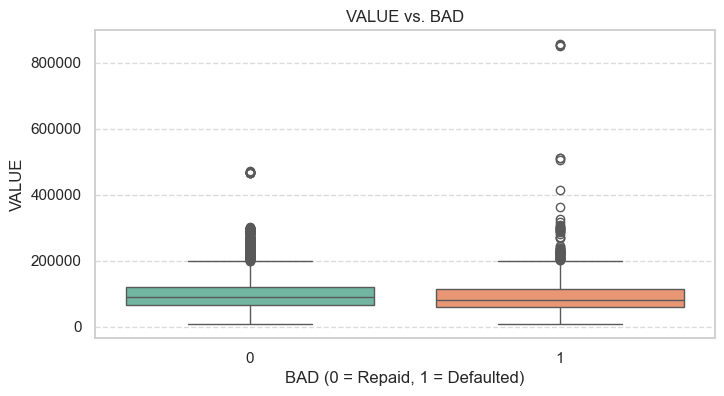

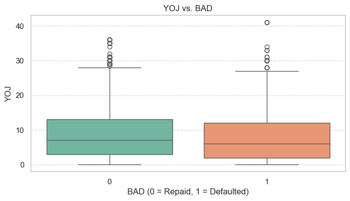

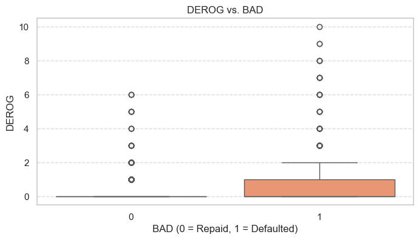

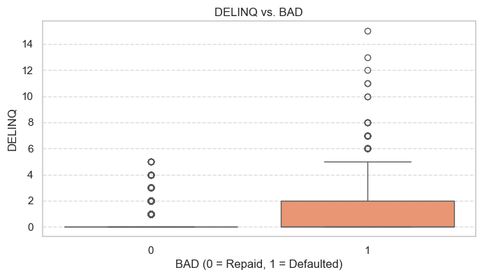

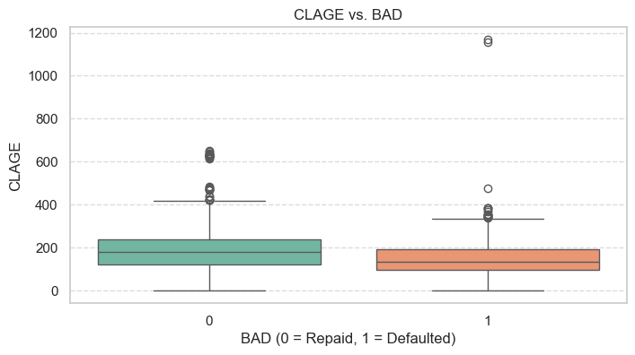

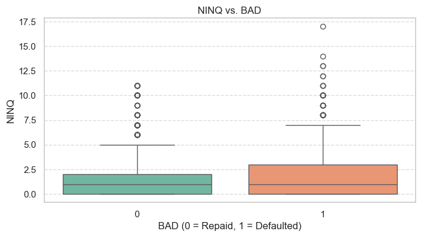

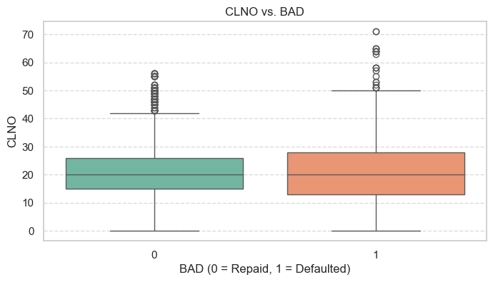

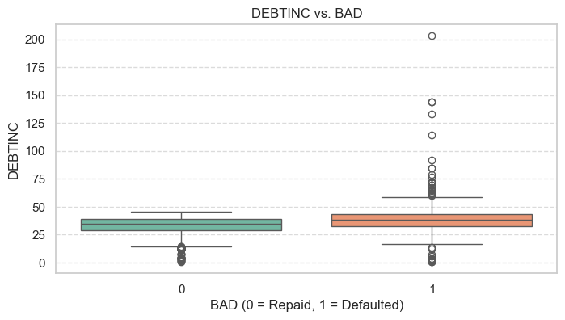

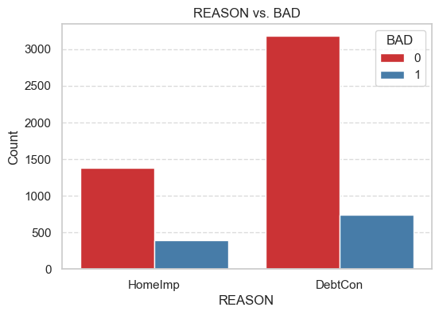

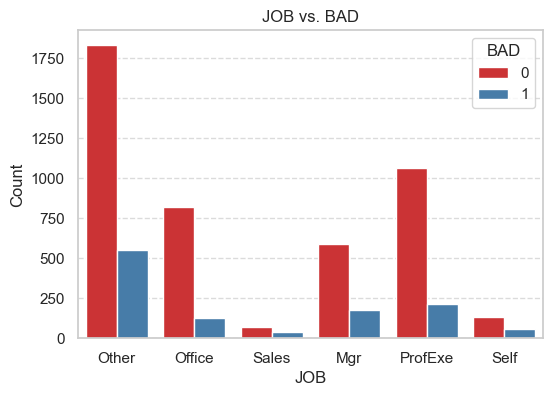

```python
# Set up the plotting environment for bivariable analysis
sns.set(style="whitegrid")

# Numerical variables vs. BAD
for column in numerical_columns:
    plt.figure(figsize=(8, 4))
    sns.boxplot(x='BAD', y=column, data=hmeq_data, palette='Set2')
    plt.title(f'{column} vs. BAD')
    plt.xlabel('BAD (0 = Repaid, 1 = Defaulted)')
    plt.ylabel(column)
    plt.grid(axis='y', linestyle='--', alpha=0.7)
    plt.show()

# Categorical variables vs. BAD
for column in categorical_columns:
    plt.figure(figsize=(6, 4))
    sns.countplot(x=column, hue='BAD', data=hmeq_data, palette='Set1')
    plt.title(f'{column} vs. BAD')
    plt.xlabel(column)
    plt.ylabel('Count')
    plt.grid(axis='y', linestyle='--', alpha=0.7)
    plt.legend(title='BAD', loc='upper right')
    plt.show()
```

### **Observations from Bivariable Analysis:**

#### **Numerical Variables vs. BAD:**

**VALUE (Property Value):**

Property values of defaulters are slightly lower on average compared to non-defaulters.

**YOJ (Years at Present Job):**

Applicants with fewer years at their current job are more likely to default, though the differences are subtle.

**DEROG (Number of Major Derogatory Reports):**

Defaulters have more derogatory reports on average compared to non-defaulters.

**DELINQ (Number of Delinquent Credit Lines):**

Higher delinquencies are associated with a higher likelihood of default.

**CLAGE (Age of Oldest Credit Line):**

No clear trend, but defaulters have slightly younger credit lines.

**NINQ (Number of Recent Credit Inquiries):**

Defaulters tend to have slightly more recent credit inquiries.

**CLNO (Number of Existing Credit Lines):**

**DEBTINC (Debt-to-Income Ratio):**

**Higher debt-to-income ratios are associated with a higher likelihood of default.**

#### **Categorical Variables vs. BAD:**

**Insights:**

Several numerical predictors, such as DEBTINC, DEROG, and DELINQ, show notable differences between defaulters and non-defaulters, indicating their potential importance in predictive modeling.

**Categorical variables like REASON and JOB also display trends worth incorporating into the analysis.**

## Comparative Boxplots

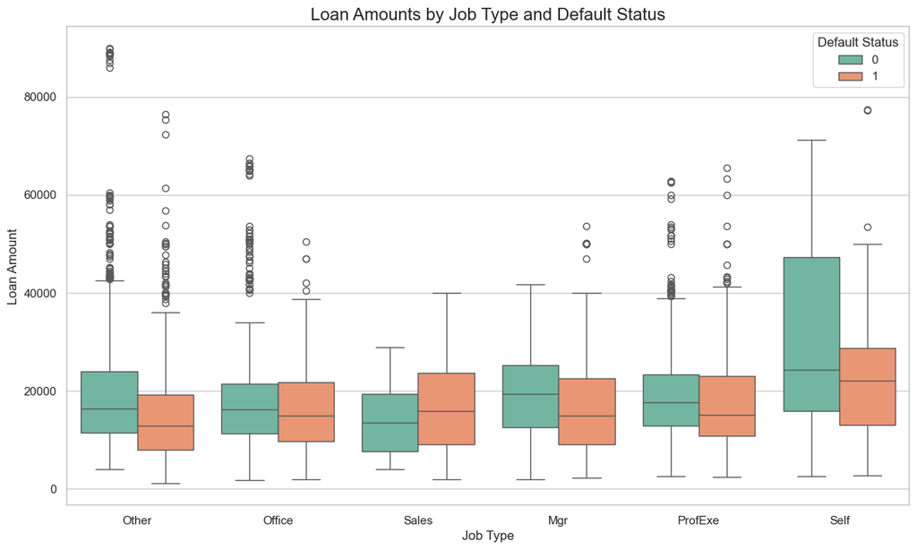

```python
# Create comparative box plots for LOAN amounts across different JOB types, differentiated by BAD status
plt.figure(figsize=(14, 8))
sns.boxplot(x='JOB', y='LOAN', hue='BAD', data=hmeq_data, palette='Set2')
plt.title('Loan Amounts by Job Type and Default Status', fontsize=16)
plt.xlabel('Job Type', fontsize=12)
plt.ylabel('Loan Amount', fontsize=12)
plt.legend(title='Default Status')
plt.show()
```

The box plots above show the distribution of loan amounts by job type, differentiated by default status (BAD). Here are some key observations:

### **Observations:**

**Variability in Loan Amounts Across Jobs:**

Different job types exhibit different ranges and medians of loan amounts, indicating varying financial profiles or borrowing needs.

**Default Status Differences:**

In most job categories, the median loan amount for defaults (BAD=1) does not significantly differ from non-defaults (BAD=0), suggesting that loan amount alone might not be a strong predictor of default when not considering other factors.

**Job Categories with Notable Differences:**

### **Interpretation**

These differences could imply that while the loan amount itself might not drastically change the likelihood of default across all job types, the financial stability and income consistency associated with certain jobs (like 'Self' or 'Sales') make higher loan amounts more risky. This suggests a nuanced relationship between job type, loan amount, and default risk, which should be explored further in risk assessment and predictive modeling.

## Scatter plots with Hue

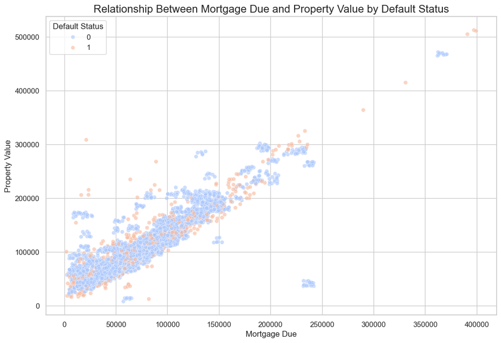

```python
# Create scatter plots to explore the relationship between MORTDUE (Mortgage Due) and VALUE (Property Value)
# with points colored by BAD status, to investigate how property equity relates to default risk.
plt.figure(figsize=(12, 8))
sns.scatterplot(x='MORTDUE', y='VALUE', hue='BAD', data=hmeq_data, palette='coolwarm', alpha=0.6)
plt.title('Relationship Between Mortgage Due and Property Value by Default Status', fontsize=16)
plt.xlabel('Mortgage Due', fontsize=12)
plt.ylabel('Property Value', fontsize=12)
plt.legend(title='Default Status')
plt.show()
```

The scatter plot above visualizes the relationship between the mortgage due (MORTDUE) and the property value (VALUE), with the default status (BAD) distinguished by color. Here are some insights from the plot:

**Observations:**

- Distribution and Trends:

Most data points are clustered towards the lower ends of both mortgage dues and property values, indicating a concentration of loans with lower values and dues. This is typical in a general lending environment where smaller loans are more common.

- Relationship Between Mortgage and Value:

There appears to be a positive correlation between the mortgage due and the property value, which is expected as higher-valued properties tend to have higher mortgages. However, there's considerable variance in this relationship, with some properties having high values but relatively lower mortgage dues.

- Default Status Indications:

Defaults (BAD=1, highlighted in red) are somewhat evenly dispersed throughout the plot but are noticeably more frequent in areas where the mortgage dues are high relative to the property value. This suggests that higher loan-to-value ratios may be associated with increased default risk. Non-defaults (BAD=0, in blue) are densely packed in regions with lower mortgage dues and moderate property values, indicating stable borrowing and lending scenarios.

### **Interpretation**

The plot suggests that while overall loan amounts and property values do influence default risk, the proportion of the mortgage due relative to the property value (an indirect measure of equity or loan-to-value ratio) could be a critical factor in default risk. Borrowers with less equity in their homes may be at higher risk of default.

It might be beneficial to calculate explicit financial ratios such as loan-to-value or debt-to-income ratios for more nuanced risk assessments.

## Overlaying Distributions

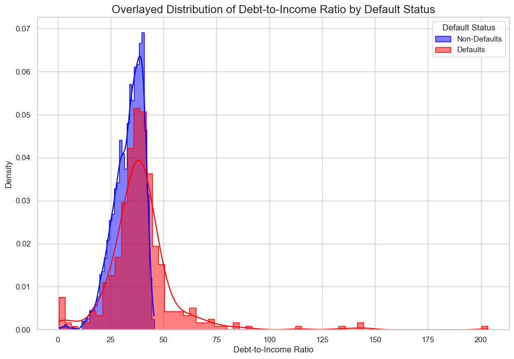

```python
# Overlay histograms for DEBTINC (Debt-to-Income Ratio) to compare distributions between defaults and non-defaults
plt.figure(figsize=(12, 8))
sns.histplot(hmeq_data[hmeq_data['BAD'] == 0]['DEBTINC'], color="blue", label='Non-Defaults', kde=True, element='step', stat="density")
sns.histplot(hmeq_data[hmeq_data['BAD'] == 1]['DEBTINC'], color="red", label='Defaults', kde=True, element='step', stat="density")
plt.title('Overlayed Distribution of Debt-to-Income Ratio by Default Status', fontsize=16)
plt.xlabel('Debt-to-Income Ratio', fontsize=12)
plt.ylabel('Density', fontsize=12)
plt.legend(title='Default Status')
plt.show()
```

The overlayed histograms for the Debt-to-Income Ratio (DEBTINC) offer a clear visual comparison between the distributions for defaults and non-defaults:

**Observations**

- Density and Range:

Non-defaults tend to concentrate around lower DEBTINC values, suggesting a general financial stability among these borrowers.

Defaults are denser at higher DEBTINC values, indicating financial strain as a common characteristic among borrowers who fail to repay their loans.

- Interpretation:

Debt-to-Income Ratio's Role: This variable is a strong predictor of default risk, as borrowers with higher debt relative to their income are more likely to default. The distribution differences support the use of DEBTINC in risk modeling, as it clearly distinguishes between default and non-default cases.

Financial Health Indicator: The DEBTINC can be used as a key indicator of financial health in lending decisions. Lenders might consider setting thresholds or more rigorous scrutiny for loans that result in higher ratios.

**This analysis confirms the importance of DEBTINC in predicting defaults and supports its inclusion in predictive models. It also suggests potential for developing threshold-based rules or more complex models that incorporate DEBTINC as a significant feature.**

## Correlation Heatmap

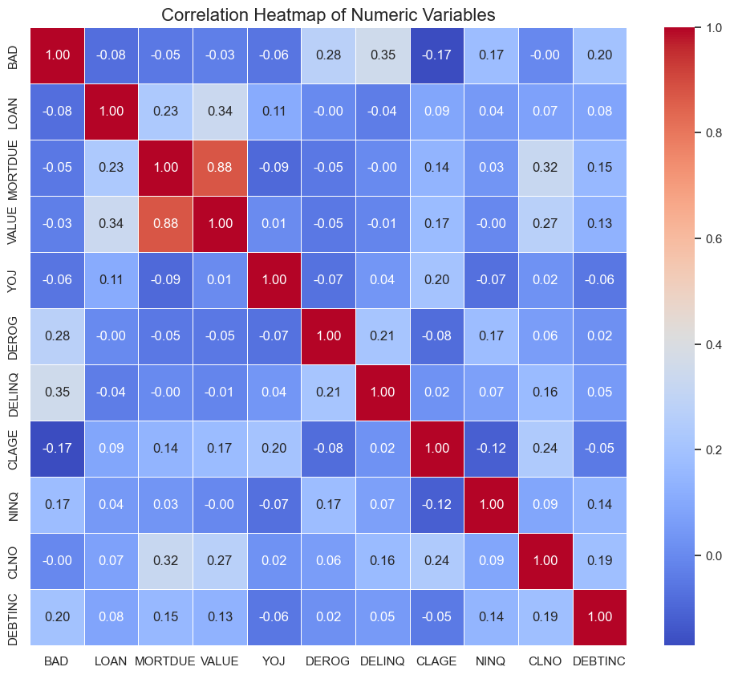

```python
# Generate a correlation matrix for numeric variables only and visualize it using a heatmap
numeric_cols = hmeq_data.select_dtypes(include=[np.number]).columns
correlation_matrix = hmeq_data[numeric_cols].corr()

plt.figure(figsize=(12, 10))
sns.heatmap(correlation_matrix, annot=True, cmap='coolwarm', fmt=".2f", linewidths=.5)
plt.title('Correlation Heatmap of Numeric Variables', fontsize=16)
plt.show()
```

### **Correlation with BAD**

**DEBTINC:** Shows a significant positive correlation with the default indicator BAD, reinforcing its importance as a predictor of default risk.

**DELINQ and DEROG:** Both have moderate to strong positive correlations with BAD, highlighting them as significant predictors.

### **Implications for Modeling**

The correlations give us insight into which variables might be most predictive of defaults and should be focused on in predictive modeling.

Multicollinearity, particularly between variables like MORTDUE and VALUE, may need to be addressed during model training to ensure the stability and interpretability of the model.

This heatmap not only confirms the relevance of specific variables for predicting loan defaults but also helps in deciding on feature selection and engineering strategies. It may be beneficial to consider interactions or create derived variables where significant correlations exist.

### **Multivariate Analysis**

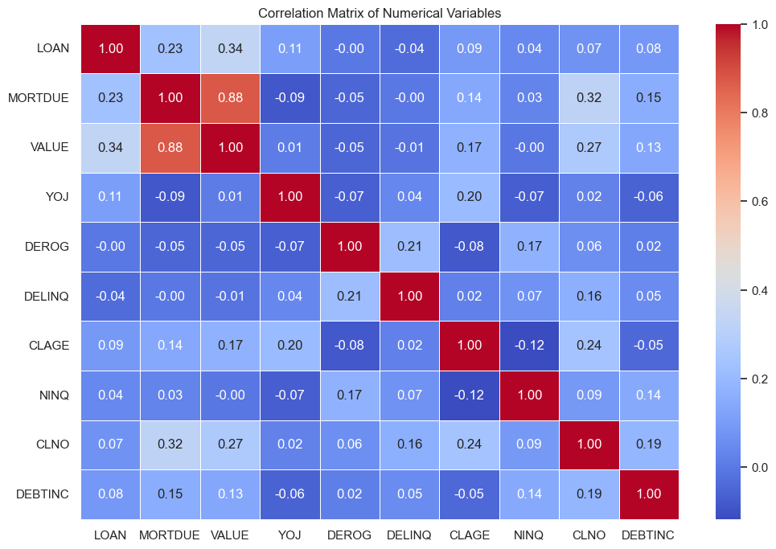

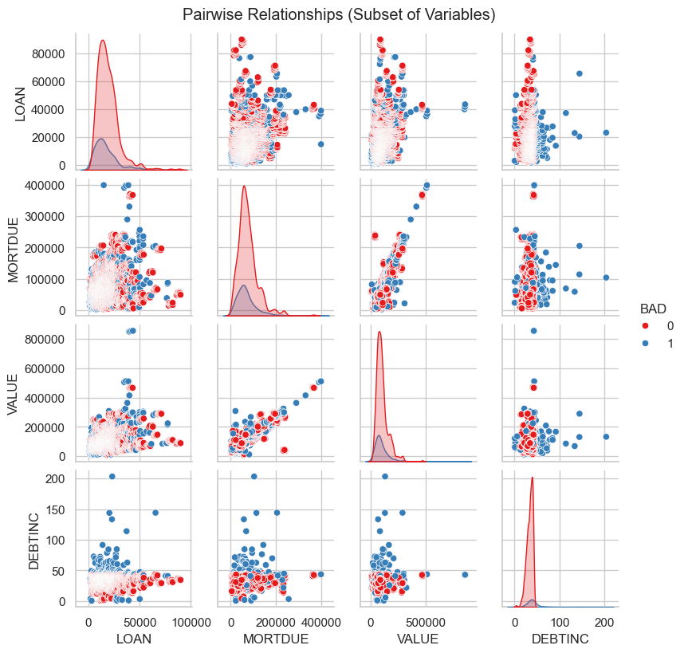

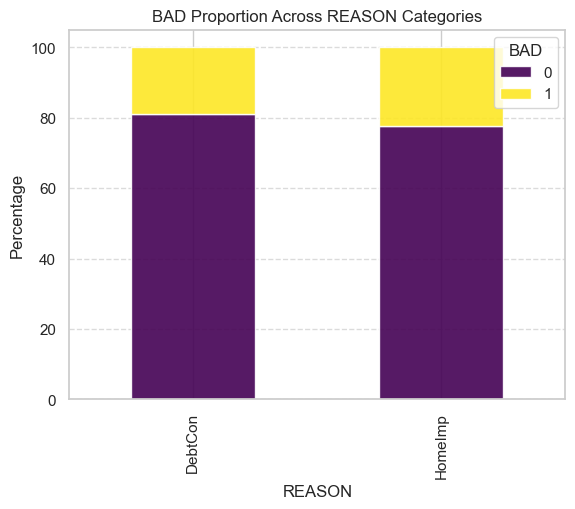

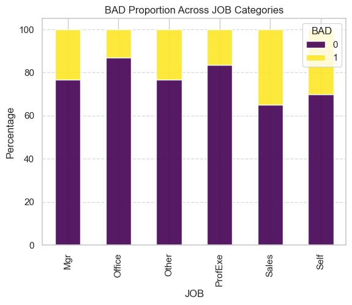

```python
# Columns setup
numerical_columns = ['LOAN', 'MORTDUE', 'VALUE', 'YOJ', 'DEROG', 'DELINQ', 'CLAGE', 'NINQ', 'CLNO', 'DEBTINC']
categorical_columns = ['REASON', 'JOB']

# Multivariable analysis: Correlation matrix for numerical variables
plt.figure(figsize=(12, 8))
correlation_matrix = hmeq_data[numerical_columns].corr()
sns.heatmap(correlation_matrix, annot=True, cmap='coolwarm', fmt='.2f', linewidths=0.5)
plt.title('Correlation Matrix of Numerical Variables')
plt.show()

# Multivariable analysis: Pairwise plots for a subset of variables and BAD
subset_columns = ['LOAN', 'MORTDUE', 'VALUE', 'DEBTINC', 'BAD']
sns.pairplot(hmeq_data[subset_columns], hue='BAD', palette='Set1', diag_kind='kde', height=2)
plt.suptitle('Pairwise Relationships (Subset of Variables)', y=1.02)
plt.show()

# Cross-tabulation for categorical variables and BAD
for column in categorical_columns:
    cross_tab = pd.crosstab(hmeq_data[column], hmeq_data['BAD'], normalize='index') * 100
    plt.figure(figsize=(8, 4))
    cross_tab.plot(kind='bar', stacked=True, colormap='viridis', alpha=0.9)
    plt.title(f'BAD Proportion Across {column} Categories')
    plt.xlabel(column)
    plt.ylabel('Percentage')
    plt.grid(axis='y', linestyle='--', alpha=0.7)
    plt.legend(title='BAD', loc='upper right')
    plt.show()
```

#### **Analysis and Insights from the Visualizations:**

- **1. Correlation Matrix (Numerical Variables)**

**Insights:**

Highly correlated variables like MORTDUE and VALUE might introduce multicollinearity in models. Consider feature reduction or dimensionality techniques. Weak correlations between most variables suggest unique contributions to default prediction.

- **2. Pairwise Relationships (Subset of Variables)**

**Insights:**

Multivariate models will likely outperform univariate or bivariate approaches. Features like DEROG, DELINQ, and DEBTINC capture distinct patterns in defaulters.

- **4. BAD Proportion Across REASON Categories**

- **5. BAD Proportion Across JOB Categories**

#### **Conclusions:**

**Feature Interactions:**

Interactions between financial metrics (e.g., DEBTINC, MORTDUE, VALUE) are crucial for capturing default patterns.

**Modeling Considerations:**

Address multicollinearity between correlated variables (MORTDUE, VALUE). Leverage non-linear models or interaction terms for better performance.